# Yifan_Wu_HW7

Yifan Wu

April 3, 2018

## Section 6.8: #11 (use LASSO): We will now try to predict per capita crime rate in the Boston data set.

### (a). Try out the lasso. Present and discuss results for the approaches that you consider.

```r
rm(list = setdiff(ls(), lsf.str()))
```

```r
library(ISLR)
library(MASS)
library(caret)
attach(Boston)
dim(Boston)
```

```
## [1] 506  14
```

```r
set.seed(11)
sample.train = sample(1:dim(Boston)[1], dim(Boston)[1] / 2) #Sample all rows, only keep half of them
sample.test = - sample.train

train <- Boston[sample.train, ]
test <- Boston[sample.test, ]
x=model.matrix(crim ~ ., data = train )[,-1]
y=train$crim
```

```r
library(glmnet)
```

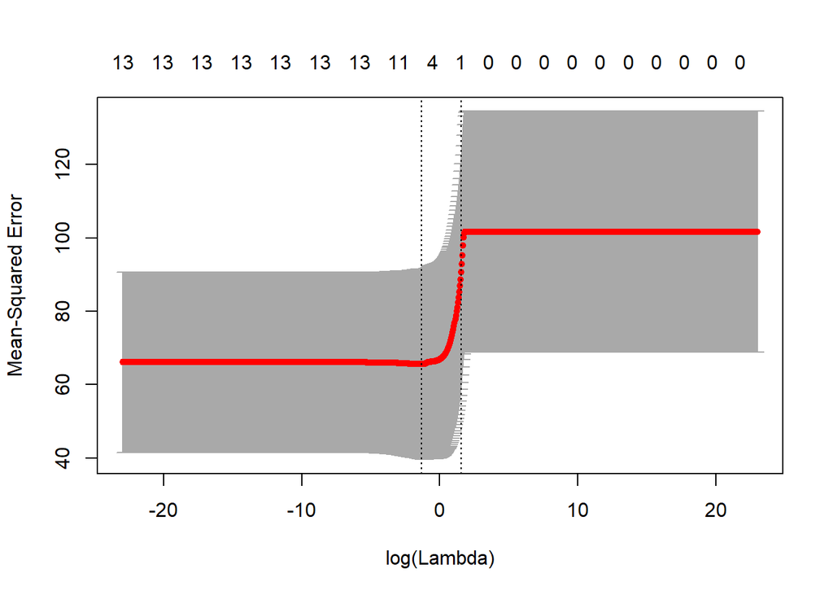

```r
grid <- 10 ^ seq(10, -10, length = 1000)

set.seed(0403)
lasso.mod =glmnet(x, y, alpha=1, lambda = grid, thresh = 1e-12)
#dim(coef(ridge.mod ))

cv.out =cv.glmnet(x, y, alpha=1, lambda = grid, thresh = 1e-12)
plot(cv.out)
```

```r
bestlam =cv.out$lambda.min
bestlam
```

```
## [1] 0.2688001
```

```r
x_test=model.matrix (crim ~., test )[,-1]
y_test=test$crim

lasso.pred = predict(lasso.mod, s=bestlam, newx=x_test)
mean((lasso.pred - y_test)^2)
```

```
## [1] 22.01936
```

Fit the model using the full data:

```r
x=model.matrix(crim~.,Boston )[,-1]
y=Boston$crim

out=glmnet(x,y,alpha=1, lambda = grid)
lasso.coef=predict(out, type = "coefficients", s = bestlam)
lasso.coef
```

```
## 14 x 1 sparse Matrix of class "dgCMatrix"
##                        1
## (Intercept)  2.360442685
## zn           0.009150106
## indus        .
## chas        -0.055945931
## nox          .
## rm           .
## age          .
## dis         -0.171501677
## rad          0.463875939
## tax          .
## ptratio      .
## black       -0.007044674
## lstat        0.120109685
## medv        -0.072472779
```

### (c). Does your chosen model involve all of the features in the data set? Why or why not?

```r
lasso.coef
```

```
## 14 x 1 sparse Matrix of class "dgCMatrix"
##                        1
## (Intercept)  2.360442685
## zn           0.009150106
## indus        .
## chas        -0.055945931
## nox          .
## rm           .
## age          .
## dis         -0.171501677
## rad          0.463875939
## tax          .
## ptratio      .
## black       -0.007044674
## lstat        0.120109685
## medv        -0.072472779
```

For the lasso model, only the following 7 predictors are involved in the model:

zn; chas; dis; rad; black, lstat, medv.

In the case of the lasso, the $l_1$ penalty has the effect of forcing some of the coefficient estimates to be exactly equal to zero when the tuning parameter $\lambda$ is sufficiently large. Hence, much like best subset selection, the lasso performs variable selection. The lasso yields models that involve only a subset of the variables.

## Section 7.9: #3 Note the intercepts, slopes, and other relevant information.

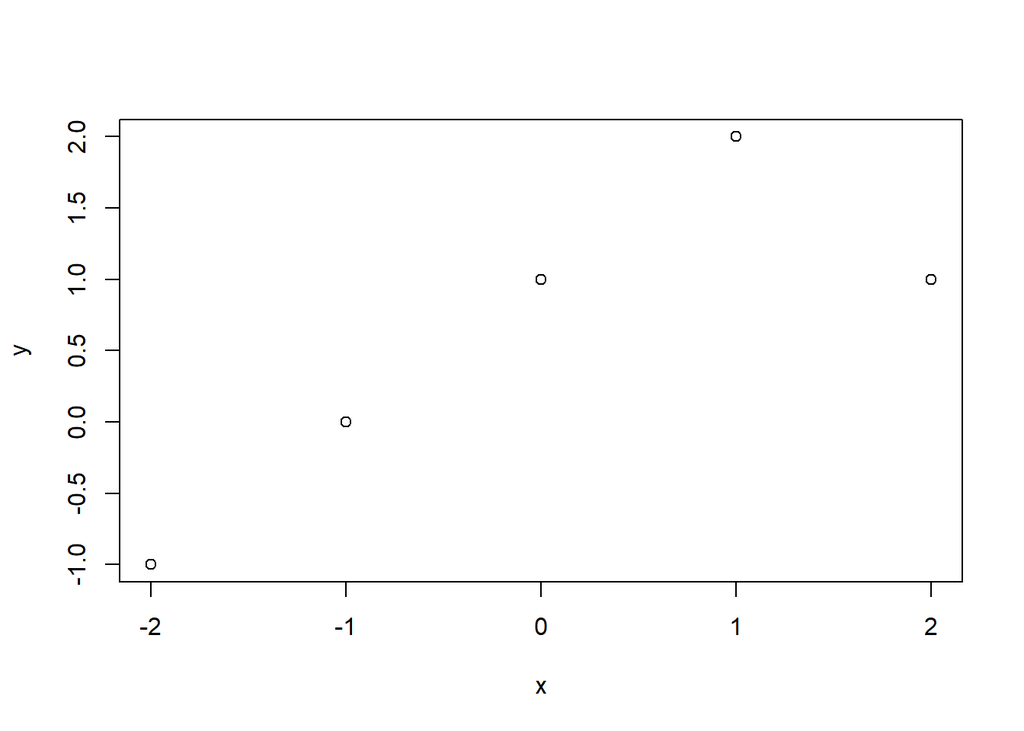

```r
x = -2:2
y = 1 + x + -2 * (x-1)^2 * I(x>=1)
plot(x, y)
```

From the plot above, the y-intercept is 1 (y = 1 when x = 0).

To the left of the vertical line x = 1, the function is linear: $y = x + 1$.

## Section 7.9: #9a-c This question uses the variables dis (the weighted mean of distances to five Boston employment centers) and nox (nitrogen oxides concentration in parts per 10 million) from the Boston data. We will treat dis as the predictor and nox as the response.

### (a). Use the poly() function to fit a cubic polynomial regression to predict nox using dis. Report the regression output, and plot the resulting data and polynomial fits.

```r
set.seed(1)
fit <- lm(nox ~ poly(dis, 3), data = Boston)
summary(fit)
```

```
##
## Call:
## lm(formula = nox ~ poly(dis, 3), data = Boston)
##
## Residuals:
##       Min        1Q    Median        3Q       Max
## -0.121130 -0.040619 -0.009738  0.023385  0.194904
##
## Coefficients:
##                Estimate Std. Error t value Pr(>|t|)
## (Intercept)    0.554695   0.002759 201.021  < 2e-16 ***
## poly(dis, 3)1 -2.003096   0.062071 -32.271  < 2e-16 ***
## poly(dis, 3)2  0.856330   0.062071  13.796  < 2e-16 ***
## poly(dis, 3)3 -0.318049   0.062071  -5.124 4.27e-07 ***
## ---
## Signif. codes:  0 '***' 0.001 '**' 0.01 '*' 0.05 '.' 0.1 ' ' 1
##
## Residual standard error: 0.06207 on 502 degrees of freedom
## Multiple R-squared:  0.7148, Adjusted R-squared:  0.7131
## F-statistic: 419.3 on 3 and 502 DF,  p-value: < 2.2e-16
```

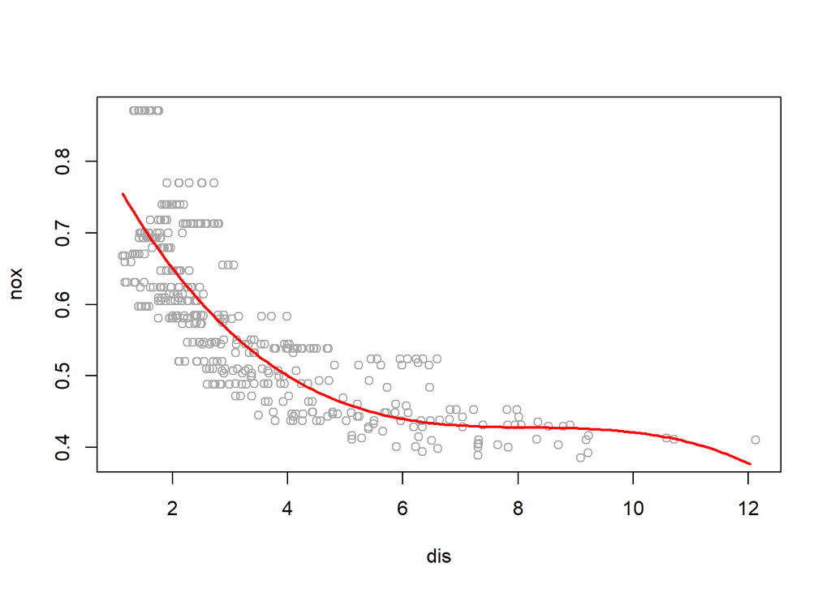

```r
dis.range <- range(Boston$dis)
dis.grid <- seq(from = dis.range[1], to = dis.range[2], by = 0.1)
preds <- predict(fit, list(dis = dis.grid))
plot(nox ~ dis, data = Boston, col = "darkgrey")
lines(dis.grid, preds, col = "red", lwd = 2)
```

### (b). Plot the polynomial fits for a range of different polynomial degrees (say, from 1 to 10), and report the associated residual sum of squares.

```r
rss <- rep(NA, 10)
for (i in 1:10){
  #set.seed(1)
  fit.i <- lm(nox ~ poly(dis, i), data = Boston)
  rss[i] <- sum(fit.i$residuals^2)
  print(sum(fit.i$residuals^2))
}
```

```
## [1] 2.768563
## [1] 2.035262
## [1] 1.934107
## [1] 1.932981
## [1] 1.91529
## [1] 1.878257
## [1] 1.849484
## [1] 1.83563
## [1] 1.833331
## [1] 1.832171
```

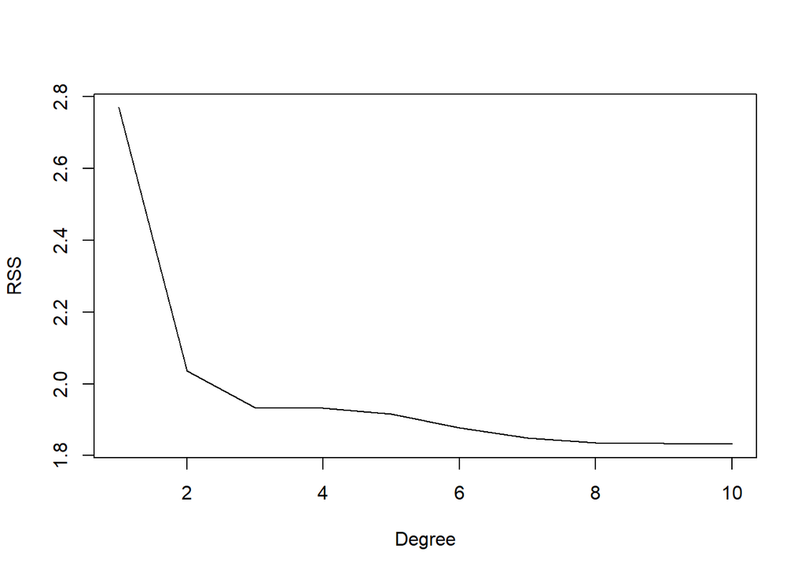

```r
plot(1:10, rss, xlab = "Degree", ylab = "RSS", type = "l")
```

As we can see from the plot, the RSS is monotonically decreasing as we increase the degree of polynomial when we fit the data.

### (c).Perform cross-validation or another approach to select the optimal degree for the polynomial, and explain your results.

```r
library (boot)
deltas <- rep(NA, 10)
for (i in 1:10) {
    fit <- glm(nox ~ poly(dis, i), data = Boston)
    deltas[i] <- cv.glm(Boston, fit, K = 10)$delta[1]
    print(paste('The ', i, 'th test MSE is', deltas[i]))
}
```

```
## [1] "The  1 th test MSE is 0.00553632883503251"
## [1] "The  2 th test MSE is 0.00407714656447925"
## [1] "The  3 th test MSE is 0.00389958728773758"
## [1] "The  4 th test MSE is 0.00386212711669392"
## [1] "The  5 th test MSE is 0.00429859032509887"
## [1] "The  6 th test MSE is 0.00509528265328026"
## [1] "The  7 th test MSE is 0.0136803273673298"
## [1] "The  8 th test MSE is 0.00528451959454986"
## [1] "The  9 th test MSE is 0.0133554128710731"
## [1] "The  10 th test MSE is 0.00414899555833493"
```

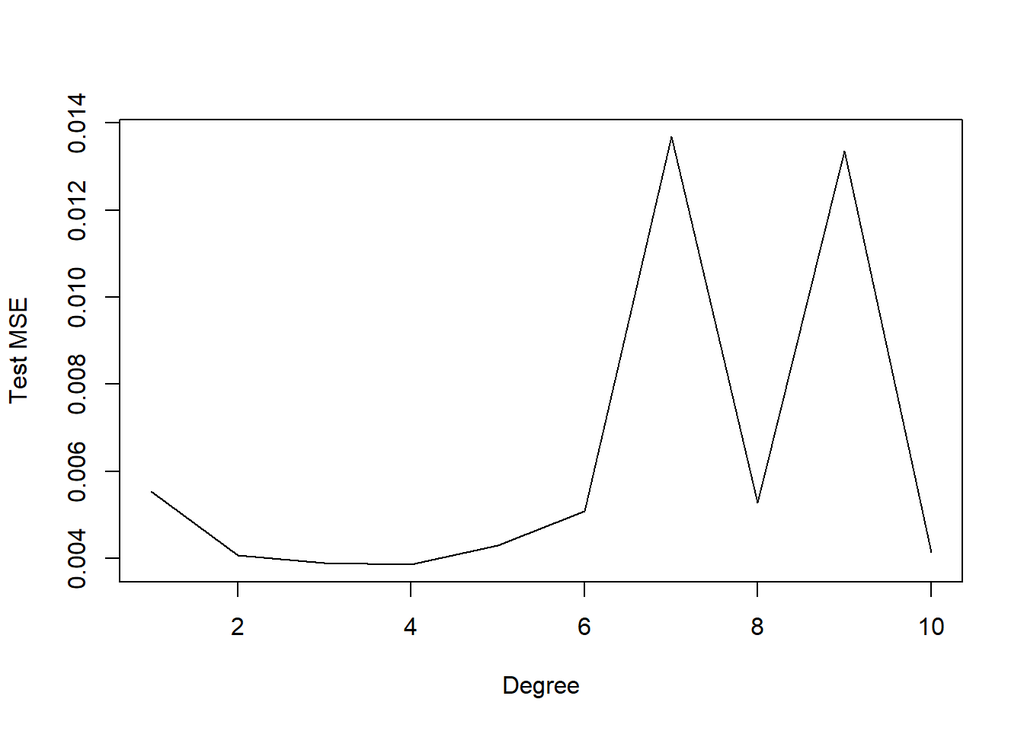

```r
plot(1:10, deltas, xlab = "Degree", ylab = "Test MSE", type = "l")
```

```r
min(deltas)
```

```
## [1] 0.003862127
```

## Section 7.9: #10ab This question relates to the College data set.

### (a). Split the data into a training set and a test set. Using out-of-state tuition as the response and the other variables as the predictors, perform forward stepwise selection on the training set in order to identify a satisfactory model that uses just a subset of the predictors.

```r
library(leaps)
set.seed(1)
attach(College)
train <- sample(length(Outstate), length(Outstate) / 2)
test <- -train
College.train <- College[train, ]
College.test <- College[test, ]
```

```r
fit <- regsubsets(Outstate ~ ., data = College.train, nvmax = 17, method = "forward")
fit.summary <- summary(fit)
fit.summary
```

```
## Subset selection object
## Call: regsubsets.formula(Outstate ~ ., data = College.train, nvmax = 17,
##     method = "forward")
## 17 Variables  (and intercept)
##             Forced in Forced out
## PrivateYes      FALSE      FALSE
## Apps            FALSE      FALSE
## Accept          FALSE      FALSE
## Enroll          FALSE      FALSE
## Top10perc       FALSE      FALSE
## Top25perc       FALSE      FALSE
## F.Undergrad     FALSE      FALSE
## P.Undergrad     FALSE      FALSE
## Room.Board      FALSE      FALSE
## Books           FALSE      FALSE
## Personal        FALSE      FALSE
## PhD             FALSE      FALSE
## Terminal        FALSE      FALSE
## S.F.Ratio       FALSE      FALSE
## perc.alumni     FALSE      FALSE
## Expend          FALSE      FALSE
## Grad.Rate       FALSE      FALSE
## 1 subsets of each size up to 17
## Selection Algorithm: forward
##           PrivateYes Apps Accept Enroll Top10perc Top25perc F.Undergrad
## 1  ( 1 )  " "        " "  " "    " "    " "       " "       " "
## 2  ( 1 )  "*"        " "  " "    " "    " "       " "       " "
## 3  ( 1 )  "*"        " "  " "    " "    " "       " "       " "
## 4  ( 1 )  "*"        " "  " "    " "    " "       " "       " "
## 5  ( 1 )  "*"        " "  " "    " "    " "       " "       " "
## 6  ( 1 )  "*"        " "  " "    " "    " "       " "       " "
## 7  ( 1 )  "*"        " "  " "    " "    " "       " "       " "
## 8  ( 1 )  "*"        " "  " "    " "    " "       " "       " "
## 9  ( 1 )  "*"        " "  "*"    " "    " "       " "       " "
## 10  ( 1 ) "*"        "*"  "*"    " "    " "       " "       " "
## 11  ( 1 ) "*"        "*"  "*"    " "    " "       " "       "*"
## 12  ( 1 ) "*"        "*"  "*"    " "    " "       " "       "*"
## 13  ( 1 ) "*"        "*"  "*"    " "    "*"       " "       "*"
## 14  ( 1 ) "*"        "*"  "*"    " "    "*"       " "       "*"
## 15  ( 1 ) "*"        "*"  "*"    " "    "*"       "*"       "*"
```

[output cut: 23 more lines]

```
## 3  ( 1 )  " "         "*"    " "
## 4  ( 1 )  "*"         "*"    " "
## 5  ( 1 )  "*"         "*"    " "
## 6  ( 1 )  "*"         "*"    "*"
## 7  ( 1 )  "*"         "*"    "*"
## 8  ( 1 )  "*"         "*"    "*"
## 9  ( 1 )  "*"         "*"    "*"
## 10  ( 1 ) "*"         "*"    "*"
## 11  ( 1 ) "*"         "*"    "*"
## 12  ( 1 ) "*"         "*"    "*"
## 13  ( 1 ) "*"         "*"    "*"
## 14  ( 1 ) "*"         "*"    "*"
## 15  ( 1 ) "*"         "*"    "*"
## 16  ( 1 ) "*"         "*"    "*"
## 17  ( 1 ) "*"         "*"    "*"
```

```r
test.mat=model.matrix(Outstate~.,data=College.test)

val.errors =rep(NA, 17)
for(i in 1:17){
  coefi=coef(fit, id=i)
  pred=test.mat[, names(coefi)]%*% coefi
  val.errors[i] = mean(( College.test$Outstate - pred)^2)
}

val.errors
```

```
##  [1] 8917567 6532569 5258792 4935504 4572478 4357411 4320173 4333668
##  [9] 4326498 4291300 4182742 4270230 4174968 4161676 4163909 4158139
## [17] 4161357
```

```r
which.min (val.errors)
```

```
## [1] 16
```

According to the result of cross validation, the model with 16 variables has the lowest validation test set error.

```r
coeffs <- coef(fit, id = 16)
coeffs
```

```
##   (Intercept)    PrivateYes          Apps        Accept        Enroll
## -1.617326e+03  2.226286e+03 -2.906482e-01  6.883981e-01 -5.459847e-02
##     Top10perc     Top25perc   F.Undergrad   P.Undergrad    Room.Board
##  2.129152e+01 -7.640046e+00 -1.459014e-01  1.598473e-01  9.451305e-01
##      Personal           PhD      Terminal     S.F.Ratio   perc.alumni
## -3.257992e-01  8.461606e+00  2.738663e+01 -8.980559e+01  5.475181e+01
##        Expend     Grad.Rate
##  1.797878e-01  3.077929e+01
```

### (b). Fit a GAM on the training data, using out-of-state tuition as the response and the features selected in the previous step as the predictors. Plot the results, and explain your findings.

```r
library(gam)
```

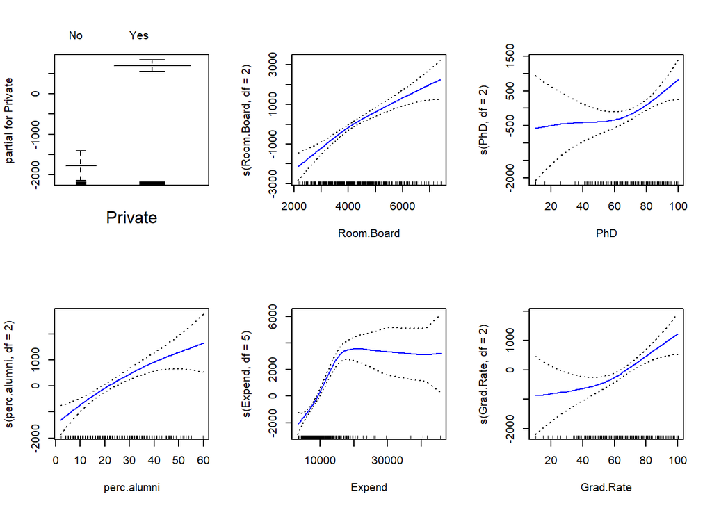

```r
fit2 <- gam(Outstate ~ Private + s(Room.Board, df = 2) + s(PhD, df = 2) + s(perc.alumni, df = 2) + s(Expend, df = 5) + s(Grad.Rate, df = 2), data=College.train)
par(mfrow = c(2, 3))
plot(fit2, se = T, col = "blue")
```

```r
preds <- predict(fit2, College.test)
err <- mean((College.test$Outstate - preds)^2)
err
```

```
## [1] 3745460
```

```r
tss <- mean((College.test$Outstate - mean(College.test$Outstate))^2)
rss <- 1 - err / tss
rss
```

```
## [1] 0.7696916
```

There is a test $R^2$ of 0.77 using GAM with 6 predictors.